# psychological network visualization using qgraph practice

reference1 : https://cran.r-project.org/web/packages/qgraph/qgraph.pdf

reference2 : Jones, P. J., Mair, P., & McNally, R. J. (2018). Visualizing psychological networks: A tutorial in R. Frontiers in Psychology, 9, 1742.

reference3 : Epskamp, S., Cramer, A. O., Waldorp, L. J., Schmittmann, V. D., & Borsboom, D. The qgraph package for network visualizations of psychometric data.

### Psychological Network Analysis, qgraph

In the field of psychometric, the relations between latent variable and manifest variable are researched, and a method to visualize the result is useful. Visualizing latent, manifest variable into a network structure is especially useful. One example may be the big five personality trait and how the traits correlate, another example may be networks of psychopathological symptoms and how it interacts. Both in the US and Europe(especially in the Netherlands), quantitative psychology is actively researched. Rigorous theoretical study regarding latent/manifest network structure will be valuable for future studies within quantitative psychology as well as applications to other fields, where research regarding multiple variables and their dynamic interaction is performed.

This page serves as personal practice of visiualizing psychological network using `qgraph`. The package heavily used is `qgraph`, and the methods are heavily borrowed from the package page and the tutorial paper by Jones, Mair, McNally. Additional reference was added which is from the maintainer and the department of psychological method from Univerisity of Amsterdam.

### Setup

```r
# Load data
library(MPsychoR)
data(Rogers) ; data(Rogers_Adolescent)
library(tidyverse)
Rogers <- as_tibble(Rogers) ; Rogers_Adolescent <- as_tibble(Rogers_Adolescent)
Rogers
```

```
## # A tibble: 408 x 26
##    onset middle  late hypersom   sad decappetite incappetite weightloss
##    <int>  <int> <int>    <int> <int>       <int>       <int>      <int>
##  1     0      2     0        1     2           0           0          0
##  2     3      2     0        0     1           0           0          0
##  3     2      1     2        0     2           0           0          0
##  4     0      3     1        2     2           0           0          0
##  5     0      2     1        1     1           0           0          0
##  6     1      1     1        2     2           2           3          2
##  7     1      0     0        1     2           0           0          0
##  8     3      2     2        0     1           1           0          1
##  9     2      0     0        2     2           2           2          2
## 10     2      3     3        0     3           1           0          0
## # ... with 398 more rows, and 18 more variables: weightgain <int>,
## #   concen <int>, guilt <int>, suicide <int>, anhedonia <int>,
## #   fatigue <int>, retard <int>, agitation <int>, obtime <int>,
## #   obinterfer <int>, obdistress <int>, obresist <int>, obcontrol <int>,
## #   comptime <int>, compinterf <int>, compdis <int>, compresis <int>,
## #   compcont <int>
```

```r
Rogers_Adolescent
```

```
## # A tibble: 87 x 26
##    onset middle  late hypersom   sad decappetite incappetite weightloss
##    <int>  <int> <int>    <int> <int>       <int>       <int>      <int>
##  1     1      0     0        2     1           0           0          0
##  2     3      2     0        1     1           0           0          0
##  3     1      2     0        0     1           1           1          1
##  4     0      0     1        3     0           0           0          0
##  5     3      3     1        0     2           0           1          0
##  6     1      0     0        0     0           0           0          0
##  7     2      0     0        1     1           1           0          0
##  8     1      1     0        0     3           0           0          0
##  9     1      2     2        1     3           1           0          1
## 10     1      3     2        1     2           0           0          0
## # ... with 77 more rows, and 18 more variables: weightgain <int>,
## #   concen <int>, guilt <int>, suicide <int>, anhedonia <int>,
## #   fatigue <int>, retard <int>, agitation <int>, obtime <int>,
## #   obinterfer <int>, obdistress <int>, obresist <int>, obcontrol <int>,
## #   comptime <int>, compinterf <int>, compdis <int>, compresis <int>,
## #   compcont <int>
```

```r
# Data Handling
colnames(Rogers) <- colnames(Rogers_Adolescent) <- 1:26
```

### Visualization & Misinterpretation

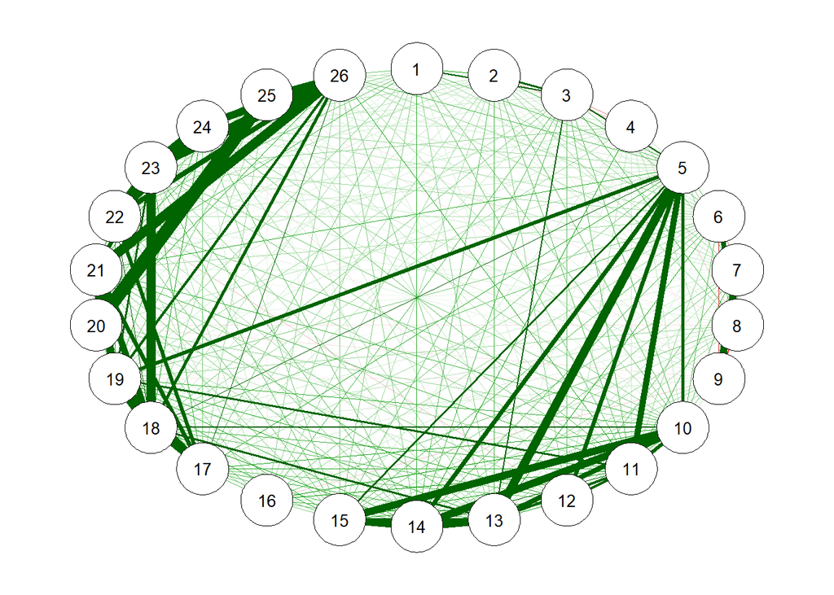

```r
# Plot Rogers
library(qgraph)
adult_zeroorder = cor(Rogers)
qgraph(adult_zeroorder)
```

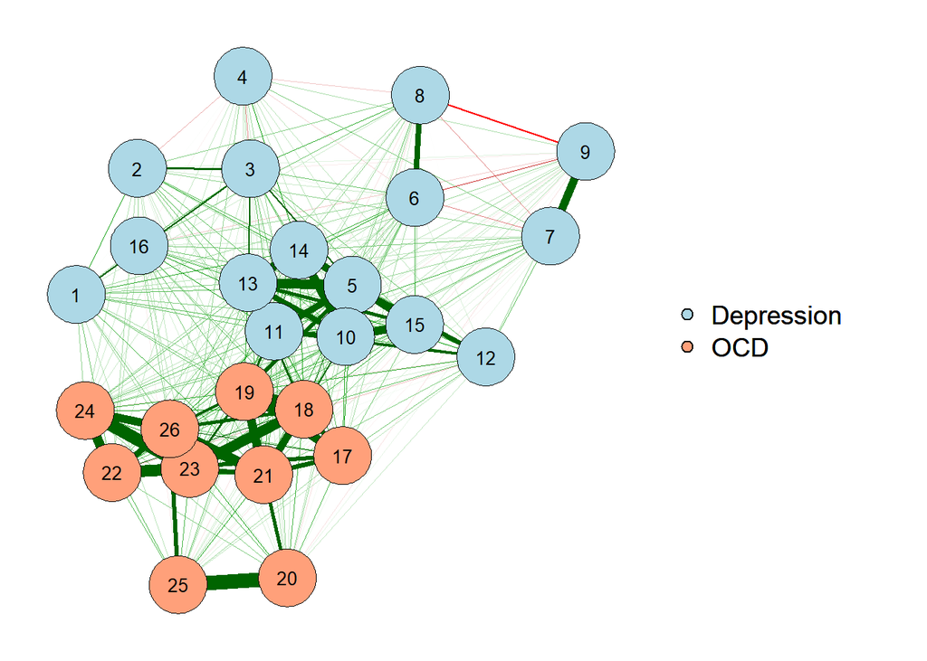

```r
qgraph(adult_zeroorder,
       layout = "spring",
       groups = list("Depression" = 1:16, "OCD" = 17:26),
       color = c("lightblue", "lightsalmon"))
```

`qgraph` takes correlation matrix of the data as input(as well as different objects), and results a graph showing correlation between variables. `layout = "spring"` option uses Fruchterman-Reingold (FR) algorithm to plot graphs in a way that minimizes overlap between edges, making the graphs visually appealing. However, it is warned in tutorial paper that the spatial positioning should not be interpretted as to have special meaning.

### Multidimensional Scaling of Networks

MDS represents proximities among variables as distances between points in a low-dimensional space. Hence, it suits us with our goal of visualizing multi variable relation in 2d space. Proximities may be such as correlations, partial correlations or Euclidean distances.

```r
# Performing MDS
library(smacof)
dissimilarity_adult <- sim2diss(adult_zeroorder)
adult_MDS <- mds(dissimilarity_adult)
adult_MDS_mspline <- mds(dissimilarity_adult,
                         type = "mspline")
```

Perform the required transformations, transformation options include `ordinal`, `ratio`, `interval`. Methods to choose the best transformation is given in paper.

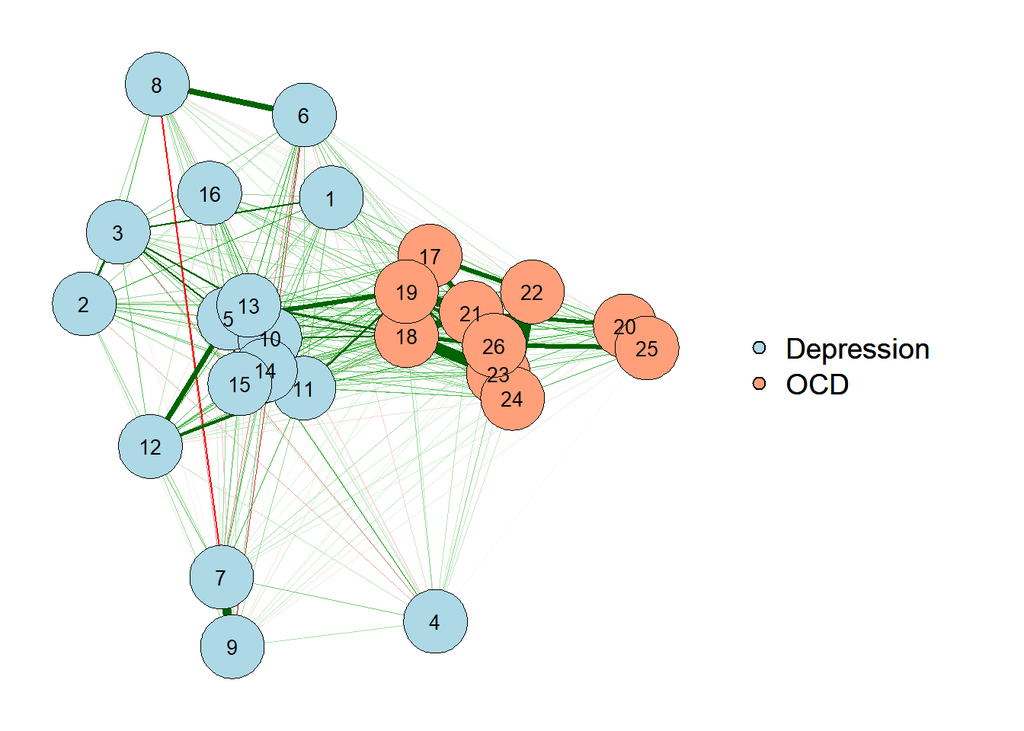

```r
# Visualize
qgraph(adult_zeroorder,
       layout = adult_MDS_mspline$conf,
       groups = list("Depression" = 1:16, "OCD" = 17:26),
       color = c("lightblue", "lightsalmon"))
```

Can visualize network based on zero-correlation coefficients. (of course visualizing with partial correlation is also possible)

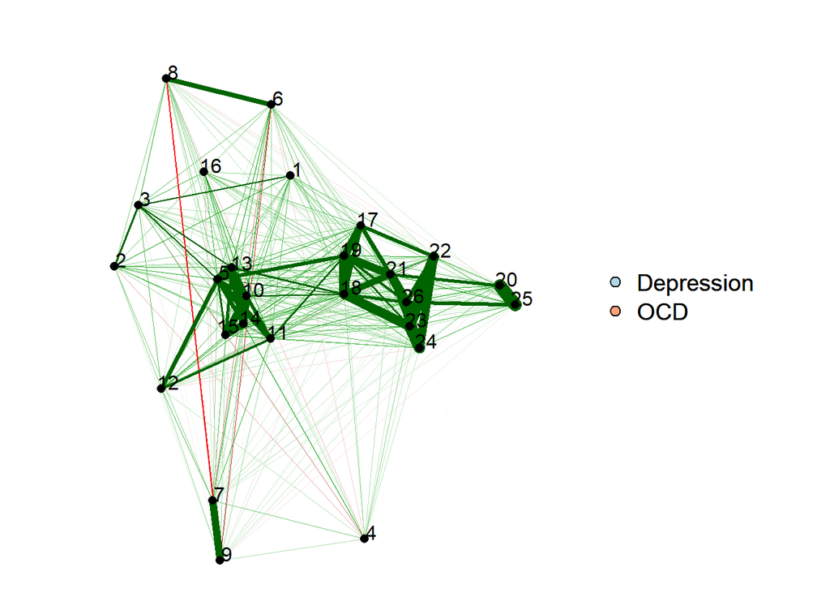

```r
# Visualize with small nodes
library(wordcloud)
qgraph(adult_zeroorder,
       layout = adult_MDS_mspline$conf,
       groups = list("Depression" = 1:16, "OCD" = 17:26),
       color = c("lightblue", "lightsalmon"),
       vsize = 0, rescale = FALSE, labels = FALSE)
points(adult_MDS_mspline$conf, pch = 16)
textplot(adult_MDS_mspline$conf[,1] + .03,
         adult_MDS_mspline$conf[,2] + .03,
         colnames(adult_zeroorder),
         new = F)
```

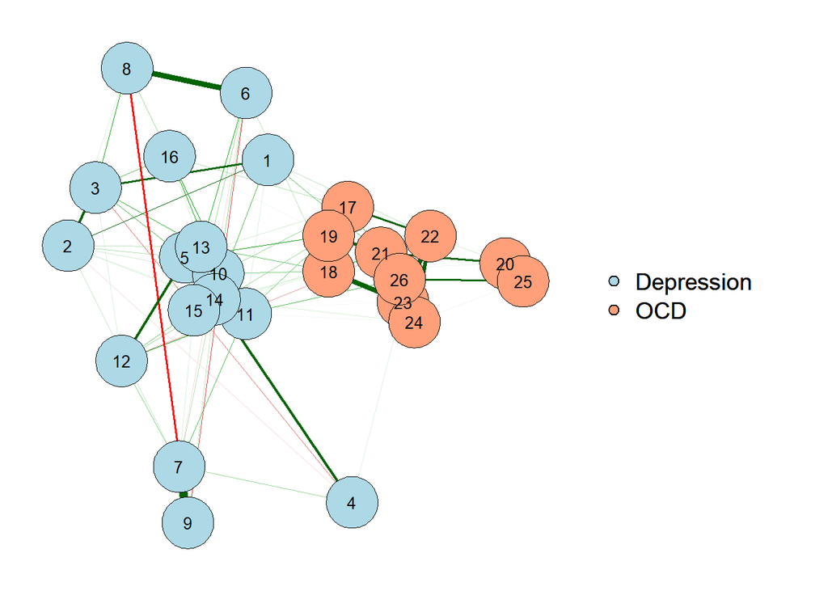

```r
# Visualize with EBICglasso
adult_glasso <- EBICglasso(cor(Rogers), n = 408)
qgraph(adult_glasso,
       layout = adult_MDS_mspline$conf,
       groups = list("Depression" = 1:16, "OCD" = 17:26),
       color = c("lightblue", "lightsalmon"))
```

Can visualize *partial correlation* on *zero-correlation space*, hence the layout is given by the zero-correlation between variables, whereas the edge thickness shows regularized partial correlation.

to be continued..